# Описательные статистики

## ЧАСТЬ 1. Характеризуем данные

## Интуитивно

[figure not shown]

Например, анализируя каждое значение в выборке по мере поступления. Даже ничего не считая специально, мы примерно понимаем, какой сорт молока дороже, какой дешевле.

## Через связки описательных статистик

### Statistics of location / Центральные тенденции

### Statistics of dispersion / Меры разброса

## ЧАСТЬ 2. Медиана и квартили.

## Медиана

Предположим, мы занимаемся селекцией яблонь и хотим охарактеризовать урожай нашей любимой яблони, на которую мы возлагаем большие надежды.

```r
apples <- c(7.3, 9.7, 10.1,  9.5,  8.0,  9.2,  7.9,  9.1)
apples
```

```
## [1]  7.3  9.7 10.1  9.5  8.0  9.2  7.9  9.1
```

## Медиана

Наши данные в исходном виде выглядят примерно так:

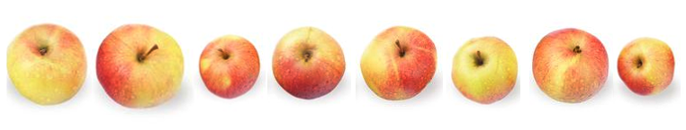

Чтобы увидеть медиану, мы должны ранжировать, или отсортировать, наш вектор по возрастанию:

```r
sort(apples)
```

```
## [1]  7.3  7.9  8.0  9.1  9.2  9.5  9.7 10.1
```

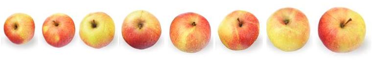

## Медиана

В ранжированном ряду медиана расположена так, что слева и справа от нее находится равное число измерений.

```r
sort(apples)
```

```
## [1]  7.3  7.9  8.0  9.1  9.2  9.5  9.7 10.1
```

Медиана находится в промежутке между значениями 9.1 и 9.2, т.е. 9.15

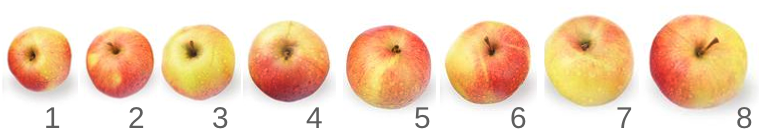

```r
median(apples) # Проверим себя
```

```
## [1] 9.15
```

## Медиана: устойчивость к выбросам

Медиана обладает чрезвычайно приятным свойством – устойчивостью к выбросам.

Представим, что наше распределение пострадало от неаккуратности. Допустим сотрудник, которому мы поручили измерять яблоки, измерил также диаметр арбуза и записал этот результат вместе со всеми остальными.

```r
apples2 <- c(apples, 68) # Создадим вектор с новым значением
sort(apples2)
```

```
## [1]  7.3  7.9  8.0  9.1  9.2  9.5  9.7 10.1 68.0
```

Медиана теперь равна 9.2

```r
median(apples2)
```

```
## [1] 9.2
```

## Медиана: устойчивость к выбросам

Давайте для сравнения посмотрим на среднее.

```r
mean(apples)
```

```
## [1] 8.85
```

```r
mean(apples2)
```

```
## [1] 15.4
```

Как видим, оно не так благополучно пережило это вторжение. Единственное неверное измерение сместило среднее значение из разряда довольно крупных яблок в область гигантских грейпфрутов.

## Квантили

Квантили — это значения, которые делят распределение на равные части.

Они называются по-разному в зависимости от числа частей.

Примеры квантилей:

- 2-квантиль (“два-квантиль”) — медиана
- 4-квантиль (“четыре-квантиль”)— квартиль
- 100-квантиль (“сто-квантиль”)— перцентиль

## Квартили

Квартиль — частный случай квантиля.

Квартили делят распределение на **четыре** равные части, каждая из которых включает по 25% значений.

- I квартиль отсекает как раз 25%.
- II квартиль — 50%. Это медиана.
- III квартиль отсекает 75% значений.

Определим их с помощью команды `quantile`

```r
quantile(x = apples, probs = c(0.25, 0.5, 0.75))
```

```
##  25%  50%  75%
## 7.97 9.15 9.55
```

## 5-number summary

Функция `quatile(x)` без указания значений вероятностей (`probs`) покажет нам квартили, минимум и максимум.

```r
quantile(apples)
```

```
##    0%   25%   50%   75%  100%
##  7.30  7.97  9.15  9.55 10.10
```

5-number summary — удобное краткое описание данных.

## Персентили

Персентиль — это частный случай квантиля. Всего 99 персентилей, они делят ряд наблюдений на 100 частей.

Ничто не помешает нам узнать, например, какие значения отсекают 10% или 99% значений выборки. Подставим соответствующие аргументы:

```r
quantile(apples, probs = c(0.1, 0.99))
```

```
##   10%   99%
##  7.72 10.07
```

## Боксплот: 5-number summary на графике

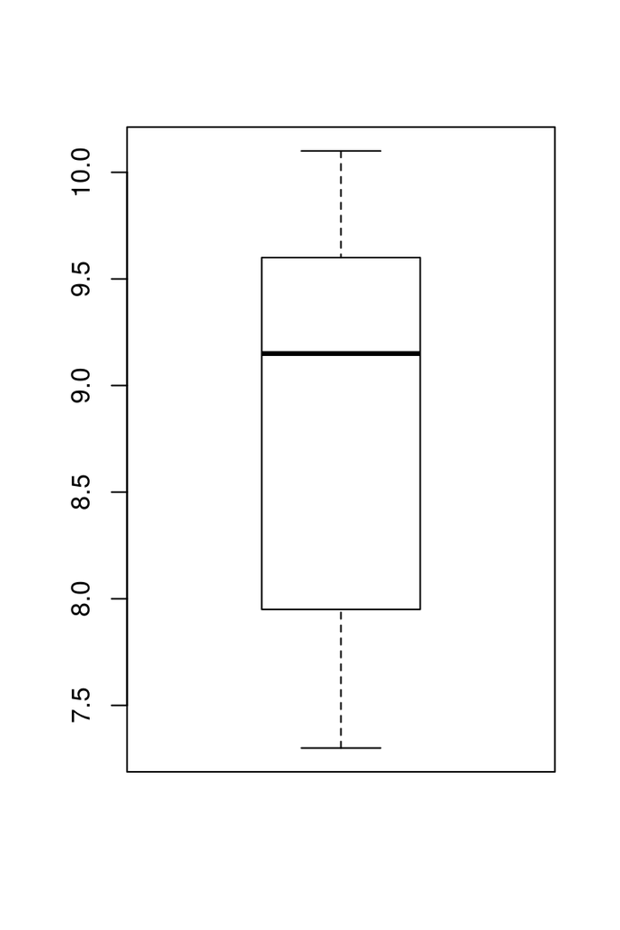

```r
boxplot(apples)
```

Отложим числа, характеризующие выборку, по оси Y:

- жирная линия в центре это медиана,
- нижняя и верхняя границы “коробочки” это I и III квантили,
- усы достигают минимального и максимального значений.

Расстояние между I и III квартилями (высота “коробочки”) называется *интерквартильное расстояние*

Если в выборке присутствуют выбросы (значения, отстоящие от границ “коробочки” больше чем на 1.5 интерквартильных расстояния), то они будут изображены отдельными точками.

## Подготовим все, чтобы построить график в ggplot2

```r
library(ggplot2)
theme_set(theme_bw())

apple_data <- data.frame(diameter = apples)
head(apple_data)
```

```
##   diameter
## 1      7.3
## 2      9.7
## 3     10.1
## 4      9.5
## 5      8.0
## 6      9.2
```

## Боксплот можно построить при помощи `geom_boxplot()`

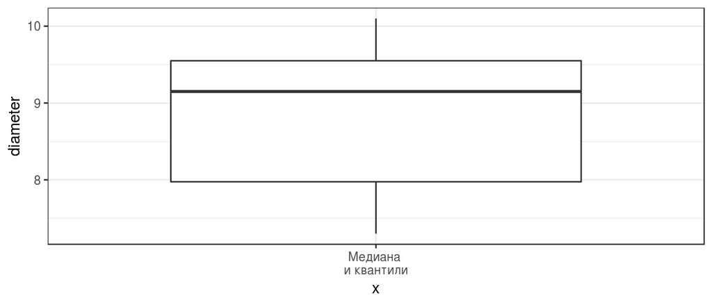

```r
ggplot(data = apple_data) +
  geom_boxplot(aes(x = 'Медиана \nи квантили', y = diameter))
```

- `x` — категория (переменная или текстовое обозначение)
- `y` — зависимая переменная

## Case study: диатомовые водоросли в желудках фильтраторов.

## Case study: диатомовые водоросли в желудках фильтраторов. Самостоятельная работа.

В морских сообществах встречаются два вида фильтраторов, один из которых любит селиться прямо на поверхности тела другого.

*Tegella armifera* это вид-хозяин. Он может жить как сам по себе, так и вместе с симбионтом.

*Loxosomella nordgardi* — вид-симбионт. Он практически никогда не встречается в одиночестве.

Данные: Юта Тамберг

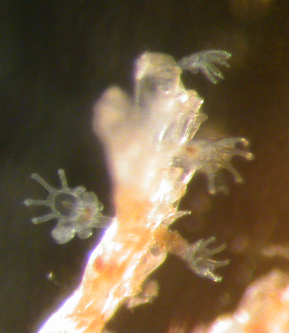

## Case study: диатомовые водоросли в желудках фильтраторов.

В файле `diatome_count.csv` даны количества диатомовых водорослей в желудках этих животных. Прочитаем эти данные и посмотрим на них:

```r
diatoms <- read.table("data/diatome_count.csv",
                      header = T, sep = "")
```

В таблице 2 переменные:

- вид (sp)
- число водорослей в желудке (count)

В переменной sp есть три варианта значений:

- “host_free” (хозяин без симбионта)
- “host_symbiont” (хозяин с симбионтом)
- “symbiont” (симбионт)

## Все ли правильно открылось?

Смотрим первые несколько строк

```r
head(diatoms)
```

```
##          sp count
## 1 host_free    10
## 2 host_free     0
## 3 host_free     1
## 4 host_free     0
## 5 host_free     2
## 6 host_free     0
```

Смотрим структуру.

```r
str(diatoms)
```

```
## 'data.frame':    162 obs. of  2 variables:
##  $ sp   : Factor w/ 3 levels "host_free","host_symbiont",..: 1 1 1 1 1 1 1 1 1 1 ...
##  $ count: int  10 0 1 0 2 0 1 0 8 0 ...
```

## Есть ли пропущенные значения?

```r
sum(! complete.cases(diatoms))
```

```
## [1] 5
```

Что это за случаи?

```r
diatoms[! complete.cases(diatoms), ]
```

```
##            sp count
## 54  host_free    NA
## 159  symbiont    NA
## 160  symbiont    NA
## 161  symbiont    NA
## 162  symbiont    NA
```

## Задание

```
##          sp count
## 1 host_free    10
## 2 host_free     0
## 3 host_free     1
## 4 host_free     0
## 5 host_free     2
## 6 host_free     0
```

Ваша задача рассчитать 5-number summary для количества диатомовых в желудках хозяев и симбионтов (всех трех категорий).

## Решение

```r
# 5-number summary для хозяев без симбионтов
host_f <- diatoms$count[diatoms$sp == "host_free"]
quantile(host_f, na.rm = TRUE)
```

```
##   0%  25%  50%  75% 100%
##    0    1    4    8   12
```

```r
# Для хозяев с симбионтами
host_s <- diatoms$count [diatoms$sp == "host_symbiont"]
quantile(host_s, na.rm = TRUE)
```

```
##    0%   25%   50%   75%  100%
##  0.00  0.25  4.50  8.00 20.00
```

```r
# Для одиноких симбионтов
symbiont <- diatoms$count [diatoms$sp == "symbiont"]
quantile(symbiont, na.rm = TRUE)
```

```
##   0%  25%  50%  75% 100%
##    0    0    1    2    7
```

## Боксплоты в ggplot2

Формат данных несколько сложен для человеческого глаза, зато очень подходит для ggplot.

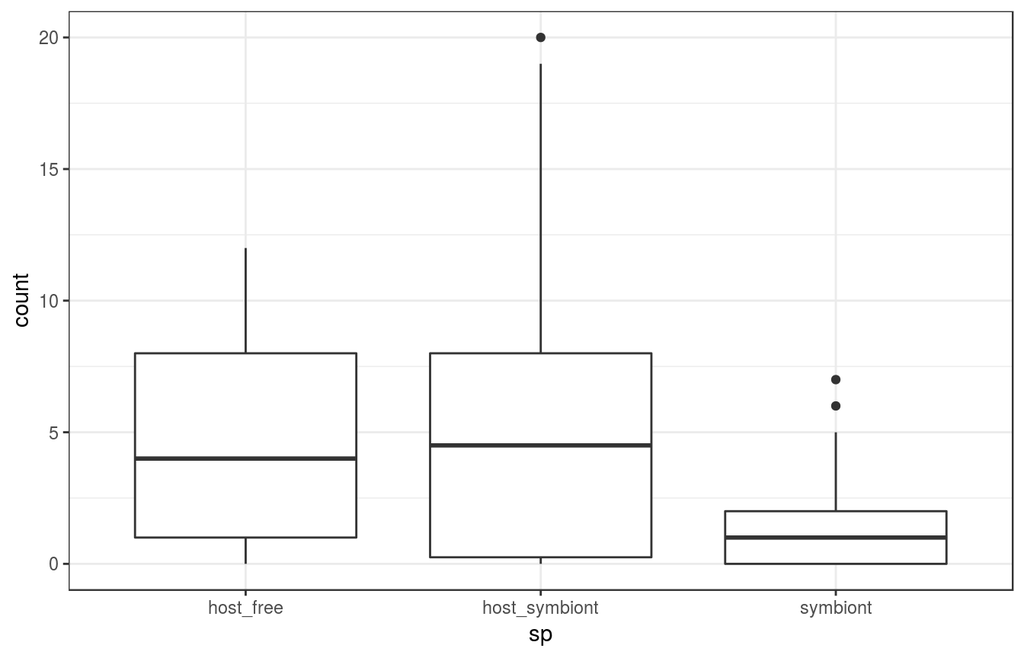

```r
ggplot(data = diatoms, aes(y = count, x = sp)) + geom_boxplot()
```

## Квартили и боксплот: непараметрические характеристики выборки

Главный плюс (но так же и минус) связки медиана + квантили это ее независимость от формы распределения.

Будь оно симметричным или с хвостом, 5-number summary опишет, а боксплот нарисует его без искажений. Однако, далеко на этих характеристиках не уедешь.

Бывают случаи, когда можно применять более специальные, но и более информативные характеристики.

## ЧАСТЬ 3. Нормальное распределение - первое знакомство

## Все распределения равны, но некоторые равнее

Это непрерывное распределение, получаемое из мерных данных. Однако, многие распределения других типов тоже могут приближаться к нормальному.

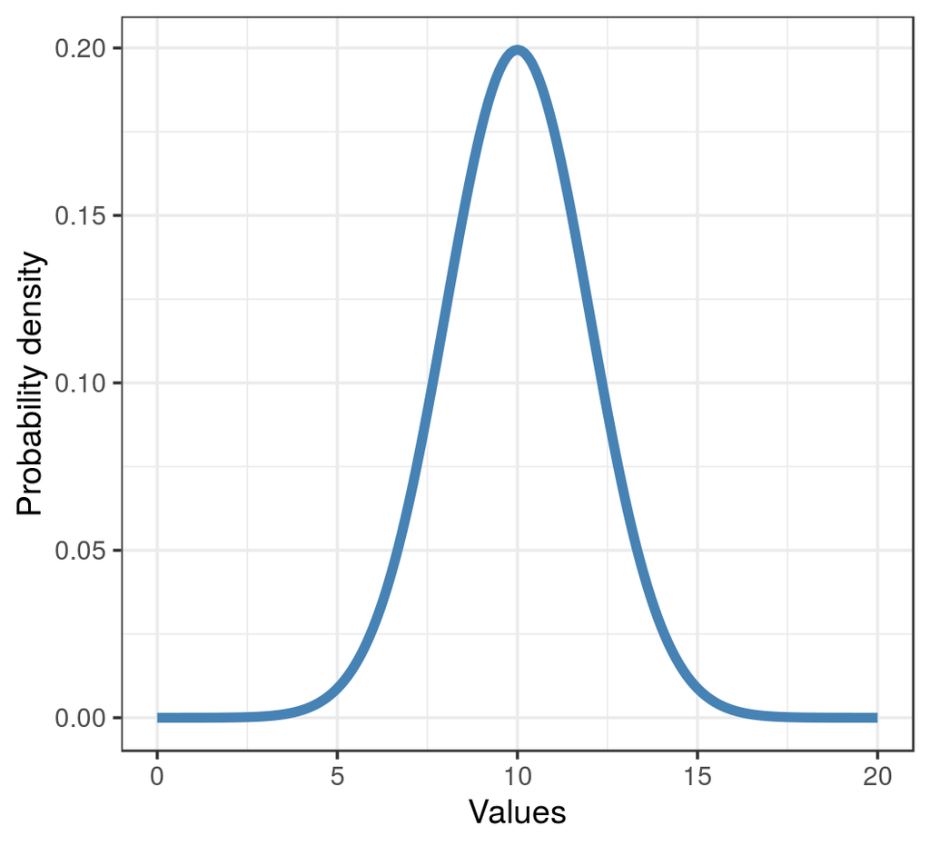

## Относительная частота и плотность вероятности

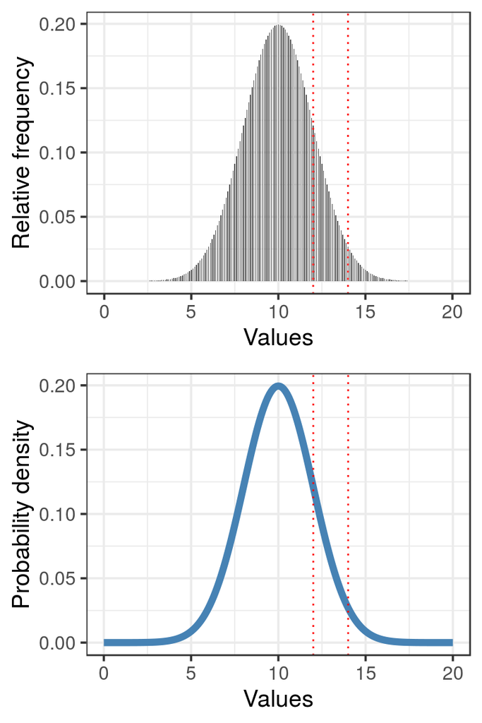

На оси Х отложены значения Х в интервале от 0 до 20, в действительности же кривая простирается от \(-\infty\) до \(+\infty\)

Площадь под кривой = 1. Интегрируя кривую на промежутке \((k,..,l)\), можно узнать вероятность встречи значений в этом промежутке \((x_k,...x_l)\).

Но нельзя рассчитать вероятность одного значения \(X = x_k\), так как это точка, и под ней нет площади.

## Приятные особенности нормального распределения

Нормальных кривых бесконечно много, и их описывает заковыристая формула с двумя параметрами (\(\mu\) и \(\sigma\)).

\[f(x) = \frac {1}{\sigma \sqrt{2 \pi}}\, e^{-\cfrac{(x-\mu)^2}{2\sigma^2}}\]

Достаточно знать эти два значения чтобы восстановить или смоделировать любое нормальное распределение.

Если:

- данные в выборке распределены нормально
- мы можем узнать или оценить параметры этого распределения

можно считать что выборка у нас в кармане! Нам больше не нужно знать результаты измерений, чтобы строить предположения о природе данных.

Так что же это за чудодейственные параметры? \(\mu\) — среднее, \(\sigma\) — стандартное отклонение.

## ЧАСТЬ 4. Среднее и стандартное отклонение

## Центральная тенденция

### Арифметическое среднее

Формула

\[\bar{x}=\frac{\sum{x_i}}{n}\]

Рассчитаем вручную и проверим:

```r
sum(apples) / length(apples)
```

```
## [1] 8.85
```

```r
mean(apples)
```

```
## [1] 8.85
```

## Как оценить разброс значений?

### Девиата (отклонение)

Это разность между значением вариаты (измерения) и средним:

\[x_i - \bar{x}\]

```r
raw_deviates <- apples - mean(apples)
raw_deviates
```

```
## [1] -1.55  0.85  1.25  0.65 -0.85  0.35 -0.95  0.25
```

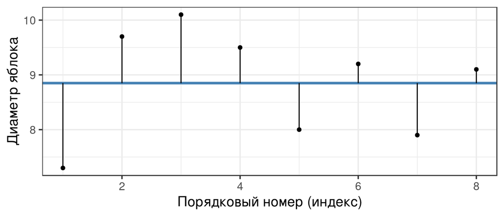

## Меры разброса

### Девиаты не годятся как мера разброса

К сожалению мы не можем просто сложить все значения девиат и поделить их на объем выборки. Сумма девиат всегда будет равна нулю.

```r
round(sum(raw_deviates))
```

```
## [1] 0
```

\[\begin{aligned} \sum{(x_i - \bar{x})} &= \sum x_i - \sum \bar x = \\ &= \sum x_i - n \bar x = \\ &= \sum x_i - n \cfrac{\sum x_i}{n} = 0 \end{aligned}\]

## Меры разброса

### Сумма квадратов = SS, Sum of Squares

Избавиться от знака девиаты можно, возведя значение в квадрат.

\[SS = \sum{{(x_i - \bar{x})}^2} \ne 0\]

```r
sum(raw_deviates^2)
```

[output not shown]

Но на что разделить \(SS\), чтобы получить меру **усредненного** отклонения значений от среднего?

## Меры разброса

### Как усреднить отклонения от среднего значения?

Мы не можем делить на \(n\), поскольку отклонения от среднего \(x_i - \bar x\) не будут независимы.

Что это значит? Сумма отклонений всегда равна нулю \(\sum{(x_i - \bar{x})} = 0\).  
Поэтому, если мы знаем \(\bar x\) и \(n - 1\) отклонений, то всегда сможем точно вычислить последнее отклонение.

\(n - 1\) — это число независимых значений (число степеней свободы).

## Меры разброса

### Дисперсия = MS, Mean Square, Variance

Если мы теперь поделим сумму квадратов на объем выборки минус 1, то получим дисперсию по этой выборке.

\[s^2=\frac{\sum{(x_i - \bar{x})^2}}{n - 1}= \frac{SS}{n - 1}\]

```r
sum(raw_deviates^2) / length(apples - 1)
var(apples)
```

[output not shown]

Дисперсию не получится нарисовать на графике, т.к. там используются не отклонения, а их квадраты

## Меры разброса

### Среднеквадратичное/стандартное отклонение = Standard Deviation

Квадратный корень из дисперсии позволит вернуться к исходным единицам измерения

\[s = \sqrt{s^2} = \sqrt{\frac{\sum{(x_i - \bar{x})^2}}{n - 1}} = SD\]

Стандартное отклонение — это средняя величина отклонения, и ее уже можно изобразить на графике.

```r
sqrt(sum(raw_deviates^2) / length(apples - 1))
sd(apples)
```

[output not shown]

## Среднее и стандартное отклонение при помощи `stat_summary()`

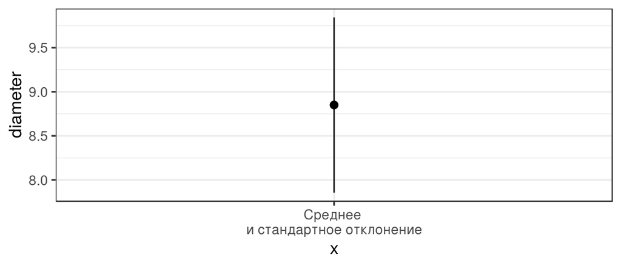

```r
ggplot(data = apple_data) +
  stat_summary(geom = 'pointrange', fun.data = mean_sdl,
               fun.args = list(mult = 1),
               aes(x = 'Среднее \nи стандартное отклонение', y = diameter))
```

`stat_summary()` использует `geom_pointrange()`  
точка — среднее, усы изображают \(\pm\) стандартное отклонение

`mean_sdl()` рассчитывает координаты точки и усов, ее аргумент `mult = 1` показывает, сколько стандартных отклонений отложить

## Особенности применения связки

- только вместе,
- чувствительны к выбросам,
- плохо работают с несимметричными распределениями.

## Сравните разброс (стандартное отклонение) в выборках

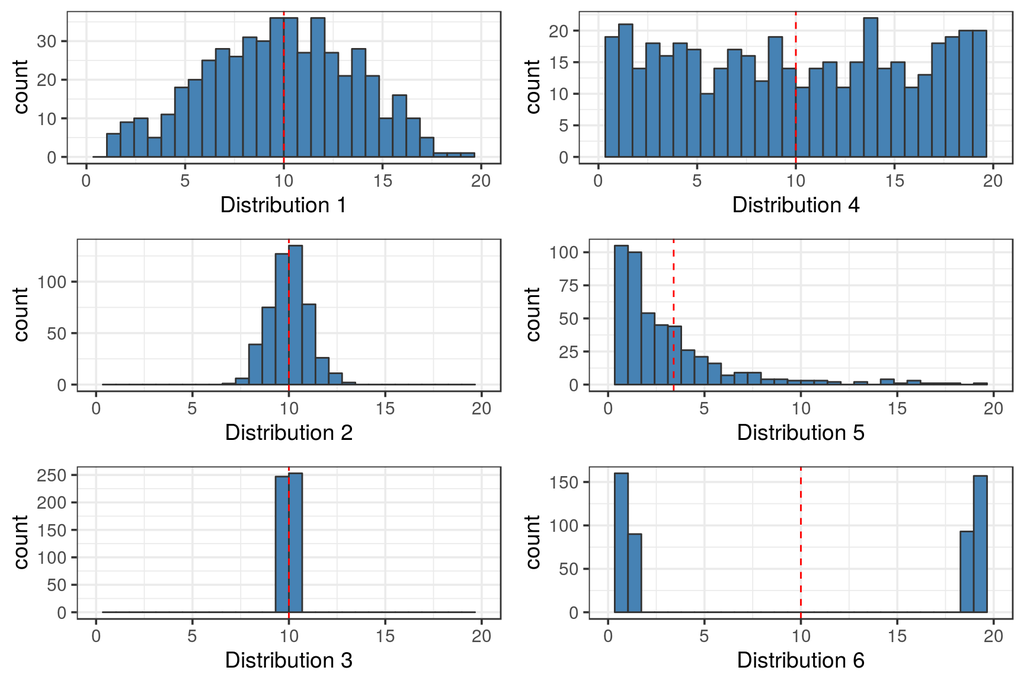

## Проверим себя

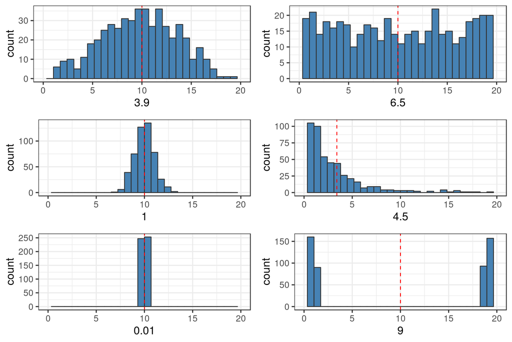

## Задание

Из пяти положительных чисел создайте выборку со средним = 10 и медианой = 7

## Решение

В выборке с медианой = 7 и n = 5, мы точно знаем: **(а)** одно из значений должно быть равно 7, **(б)** два значения должны быть меньше, и два — больше 7.

Создадим вектор, в котором одно значение задано, а три других просто придумаем:

```r
example <- c(2, 5, 7, 10)
```

Среднее это сумма всех значений выборки, поделенная на ее объем. Умножив среднее на 5 получим сумму всех значений.

Определим недостающее и проверим себя:

```r
10 * 5 - sum(example)
```

```
## [1] 26
```

```r
example <- c(2, 5, 7, 10, 26) #перезапишем вектор
mean(example)
```

```
## [1] 10
```

## Как соотносятся способы оценки центра и размаха в выборке?

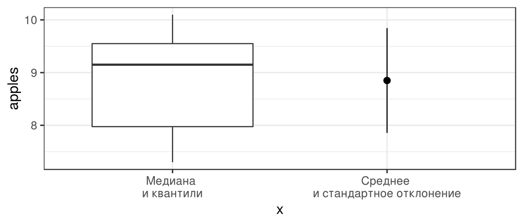

```r
ggplot(data = apple_data) +
  geom_boxplot(aes(x = 'Медиана \nи квантили', y = apples)) +
  stat_summary(geom = 'pointrange', fun.data = mean_sdl,
               fun.args = list(mult = 1),
               aes(x = 'Среднее \nи стандартное отклонение', y = diameter))
```

Медиана и среднее дают сходные результаты, если выборка не содержит выбросов (сильно отличающихся от других наблюдений).

## Take-home messages

- Описательные статистики ходят только в связке.
- Выбирая между медианой и средним, учитывайте природу данных.